# Test a Perceptual Phenomenon

### Analyzing the Stroop Effect

Perform the analysis in the space below. Remember to follow [the instructions](https://docs.google.com/document/d/1-OkpZLjG_kX9J6LIQ5IltsqMzVWjh36QpnP2RYpVdPU/pub?embedded=True) and review the [project rubric](https://review.udacity.com/#!/rubrics/71/view) before submitting. Once you've completed the analysis and write-up, download this file as a PDF or HTML file, upload that PDF/HTML into the workspace here (click on the orange Jupyter icon in the upper left then Upload), then use the Submit Project button at the bottom of this page. This will create a zip file containing both this .ipynb doc and the PDF/HTML doc that will be submitted for your project.

(1) What is the independent variable? What is the dependent variable?

The independent variable is the color of the font and the spelling of it. The dependent variable is the reaction time of the participants to name the color.

(2) What is an appropriate set of hypotheses for this task? Specify your null and alternative hypotheses, and clearly define any notation used. Justify your choices.

Null hypothesis ( $H_{0}:\mu_{i}=\mu_{c}$): The reaction time in answering the color of a word is equal to or the same when the color of the word does not match the spelling.

Alternative Hypothesis ( $H_{1}:\mu_{i}\ne\mu_{c}$): The reaction time in answering the color of a word that does not match the spelling is not equal to the reaction time when the color matches the spelling.

$\mu_{c}$ is defined as the population mean for the congruent group and $\mu_{i}$ is defined as the population mean for the incongruent group.

A t-test will be performed to determine if we fail to reject the null hypothesis, or if we will go with the alternative hypothesis.

- We will use this test to determine whether the null hypothesis that has two responses measured on the same statistical unit with a mean of zero.
- A t-test will be a prefered option as it is generally better in cases where the sample set is less than 30. In this case, we have 24 samples.
- This will also be good as we are comparing two independent variables, the color of the font and spelling for the congruent and incongruent groups.
- For this, an assumption must be made that the sampling of the distribution is normal. So if we took another sample, and took down the mean, repeated over the course of infinity times, the distribution of the bell curve would be a "perfect bell curve". Additionally, pairs of samples should be independent.

(3) Report some descriptive statistics regarding this dataset. Include at least one measure of central tendency and at least one measure of variability. The name of the data file is 'stroopdata.csv'.

```python
# Perform the analysis here
import pandas as pd
from scipy import stats
import matplotlib
import matplotlib.pyplot as plt
%matplotlib inline

df = pd.read_csv('stroopdata.csv')
df.head()
df.describe()
```

|  | Congruent | Incongruent |
| --- | --- | --- |
| count | 24.000000 | 24.000000 |
| mean | 14.051125 | 22.015917 |
| std | 3.559358 | 4.797057 |
| min | 8.630000 | 15.687000 |
| 25% | 11.895250 | 18.716750 |
| 50% | 14.356500 | 21.017500 |
| 75% | 16.200750 | 24.051500 |
| max | 22.328000 | 35.255000 |

For the congruent stimuli, the mean time for reaction is 14.05 seconds while for the incongruent, the mean time for reaction is 22.01. The maximum reaction time for the congruent stimuli is 22.32, while the maximum reaction time for the incongruent stimuli is 35.25, almost 13 seconds more. The incongruent stimuli have a greater standard deviation, showing the data points are further apart revealing longer reaction times.

(4) Provide one or two visualizations that show the distribution of the sample data. Write one or two sentences noting what you observe about the plot or plots.

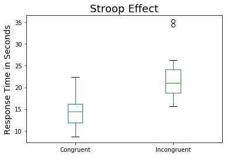

```python
df.plot.box()
plt.title("Stroop Effect", fontsize=18)
plt.xlabel(" ", fontsize=14)
plt.ylabel("Response Time in Seconds", fontsize=14)
plt.show()
```

As a result of the plots above, we see that the incongruent dataset has longer response times than the congruent dataset.

(5) Now, perform the statistical test and report your results. What is your confidence level or Type I error associated with your test? What is your conclusion regarding the hypotheses you set up? Did the results match up with your expectations? **Hint:** Think about what is being measured on each individual, and what statistic best captures how an individual reacts in each environment.

```python
stats.ttest_rel(df['Congruent'], df['Incongruent'])
```

```
Ttest_relResult(statistic=-8.020706944109957, pvalue=4.1030005857111781e-08)
```

https://www.khanacademy.org/math/ap-statistics/two-sample-inference/two-sample-t-test-means/v/two-sample-t-test-for-difference-of-means  
https://docs.scipy.org/doc/scipy/reference/tutorial/stats.html  
https://en.wikipedia.org/wiki/Stroop_effect  
http://www.dummies.com/education/math/statistics/what-a-p-value-tells-you-about-statistical-data/

https://en.wikipedia.org/wiki/Student%27s_t-test  
http://www.differencebetween.net/miscellaneous/difference-between-z-test-and-t-test/  
http://www2.psychology.uiowa.edu/faculty/mordkoff/GradStats/part%201/I.07%20normal.pdf